# 應用財務計量經濟學- HW1

魏上傑

2023-03-09

1.4

若$Y_t$為嚴格定態(strict stationary)，說明$Y_t$為具有相同分配之隨機變數。 i.e., strict stationary $\implies$ identical distributions.

2.2

(a). 讀入資料，命名為FR

```r
library(readxl)
fx <- read_excel("Reserves.xlsx")
colnames(fx) <- c("year","FR")

fx$FR <- fx$FR*(10^6) #轉為單位美元
```

```r
fx$year <- NULL #原先年資料難以操作(民國年)，所以刪除
# 新建西元年資料
fx$date <- seq(as.Date("1987-01-01"), as.Date("2022-12-01"), by="month")
fx <- fx[order(fx$date),]
```

(b). 將FR取對數，命名為LFR

```r
fx$LFR <- log(fx$FR)
```

```r
str(fx)
```

```
## tibble [432 × 3] (S3: tbl_df/tbl/data.frame)
##  $ FR  : num [1:432] 4.91e+10 5.18e+10 5.45e+10 5.75e+10 5.99e+10 ...
##  $ date: Date[1:432], format: "1987-01-01" "1987-02-01" ...
##  $ LFR : num [1:432] 24.6 24.7 24.7 24.8 24.8 ...
```

(c). 計算外匯存底年增率，命名為D12FR

```r
library(dplyr)
fx$prev_year_LFR <- lag(fx$LFR, 12)

fx$D12FR <- (fx$LFR-fx$prev_year_LFR)/fx$prev_year_LFR
```

(d). 畫出LFR, D12FR

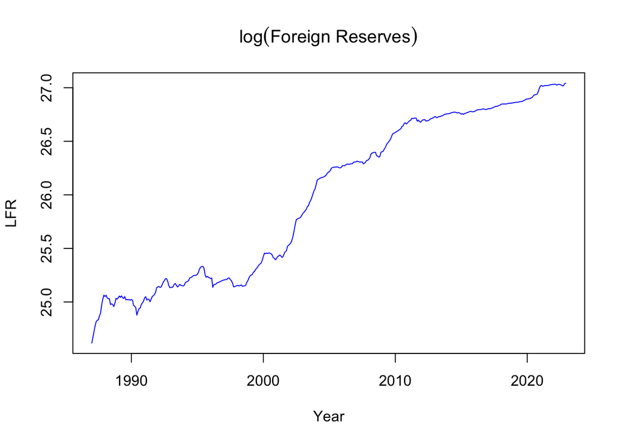

```r
plot(y=fx$LFR, x=fx$date,type="l", col="blue",
     xlab="Year", ylab="LFR",
     main=expression(log("Foreign Reserves")))
```

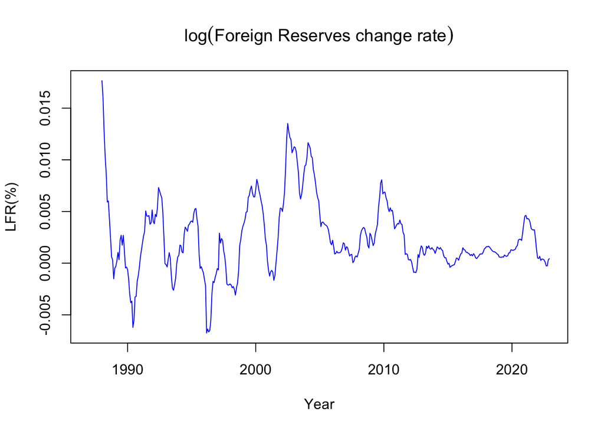

```r
plot(y=fx$D12FR, x=fx$date,type="l", col="blue",
     xlab="Year", ylab="LFR(%)",
     main=expression(log("Foreign Reserves change rate")))
```

(e). 建構虛擬變數Dum

```r
fx$Dum=0
fx$Dum <- ifelse(fx$D12FR>=0,1,0)

mean(fx$Dum, na.rm=T)
```

```
## [1] 0.8142857
```

3.1

$Y_t$是MA(1)序列：

$$Y_t=\epsilon_t+\theta\epsilon_{t-1},
\epsilon_t\sim WN(0,\sigma^2)$$
(a) 計算$\gamma(j), j\ge 0$

- if j=0:

$$\begin{equation}
\begin{split}
\gamma(0)=Cov(Y_t, Y_t)\\
=Cov(\epsilon_t+\theta\epsilon_{t-1},\epsilon_t+\theta\epsilon_{t-1})\\
=Var(\epsilon_t)+\theta^2 Var(\epsilon_{t-1})+2\theta Cov(\epsilon_t,
\epsilon_{t-1})\\
=\sigma^2+\theta^2\sigma^2+2\theta[E(\epsilon_t\epsilon_{t-1})-E(\epsilon_t)E(\epsilon_{t-1})]\\
=\sigma^2+\theta^2\sigma^2
\end{split}
\notag
\end{equation}$$

- if j=1:

$$\gamma(1)=Cov(Y_t, Y_{t-1})\\
=Cov(\epsilon_t+\theta\epsilon_{t-1},\epsilon_{t-1}+\theta\epsilon_{t-2})\\
=\theta \sigma^2$$

- if j=2:

$$\gamma(1)=Cov(Y_t, Y_{t-2})\\
=Cov(\epsilon_t+\theta\epsilon_{t-1},\epsilon_{t-2}+\theta\epsilon_{t-3})=0$$

Therefore, $\gamma(j)=0,\forall j>1$

2. $Y_t$ 是否定態?

$Y_t$ 是weakly stationary, 因為$E(Y_t)=0,\forall t,Var(Y_t)=\sigma^2+\theta^2\sigma^2<\infty,$ 並且Autocovariance只與”j”有關

事實上，finite-order MA process都是定態。

3.2

$\epsilon_t\sim WN(0,\sigma^2)$

1. $$Y_t=1.2Y_{t-1}-0.2Y_{t-2}+\epsilon_t\\
   =1.2LY_t-0.2L^2Y_t+\epsilon_t\\
   \implies (1-1.2L+0.2L^2)Y_t=\epsilon_t$$

```r
polyroot(z=c(1,-1.2,0.2))
```

```
## [1] 1+0i 5-0i
```

```r
abs(polyroot(z=c(1,-1.2,0.2)))
```

```
## [1] 1 5
```

兩個根分別為1,5，因此非定態。

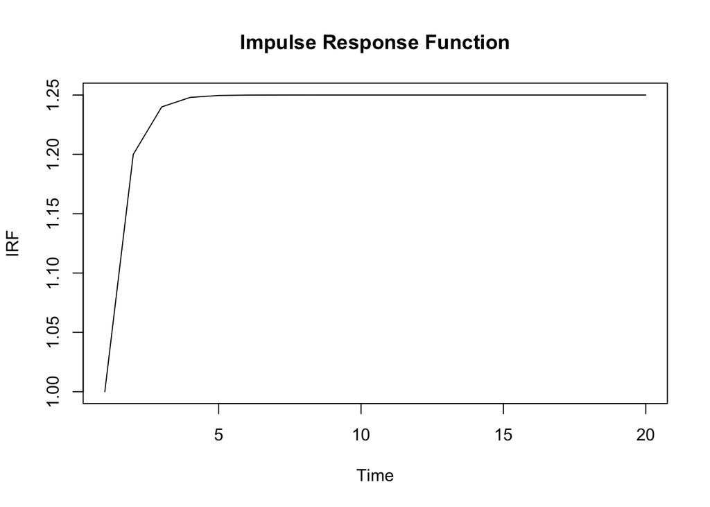

```r
set.seed(123)
e <- rnorm(n = 200, mean = 0, sd = 1)

y <- numeric(length = 200)
y.1 <- 0
y.2 <- 0
phi1 <- 1.2
phi2 <- -0.2

for (i in 1:length(y)) {
  y[i] <- phi1*y.1 + phi2*y.2 + e[i]
  y.2 <- y.1
  y.1 <- y[i]
}

# 計算IRF
irf <- numeric(length = 20)
irf[1] <- 1
for (i in 2:length(irf)) {
  if (i == 2) {
    irf[i] <- phi1
  } else {
    irf[i] <- irf[i-1]*phi1 + irf[i-2]*phi2
  }
}

# 繪製IRF
plot(irf, type = "l", main = "Impulse Response Function", xlab = "Time", ylab = "IRF")
```

2. $$Y_t=1.2Y_{t-1}-0.4Y_{t-2}+\epsilon_t\\
   =1.2LY_t-0.4L^2Y_t+\epsilon_t\\
   \implies (1-1.2L+0.4L^2)Y_t=\epsilon_t$$

```r
polyroot(z=c(1,-1.2,0.4))
```

```
## [1] 1.5+0.5i 1.5-0.5i
```

```r
abs(polyroot(z=c(1,-1.2,0.4)))
```

```
## [1] 1.581139 1.581139
```

兩個根的絕對值>1，因此定態。

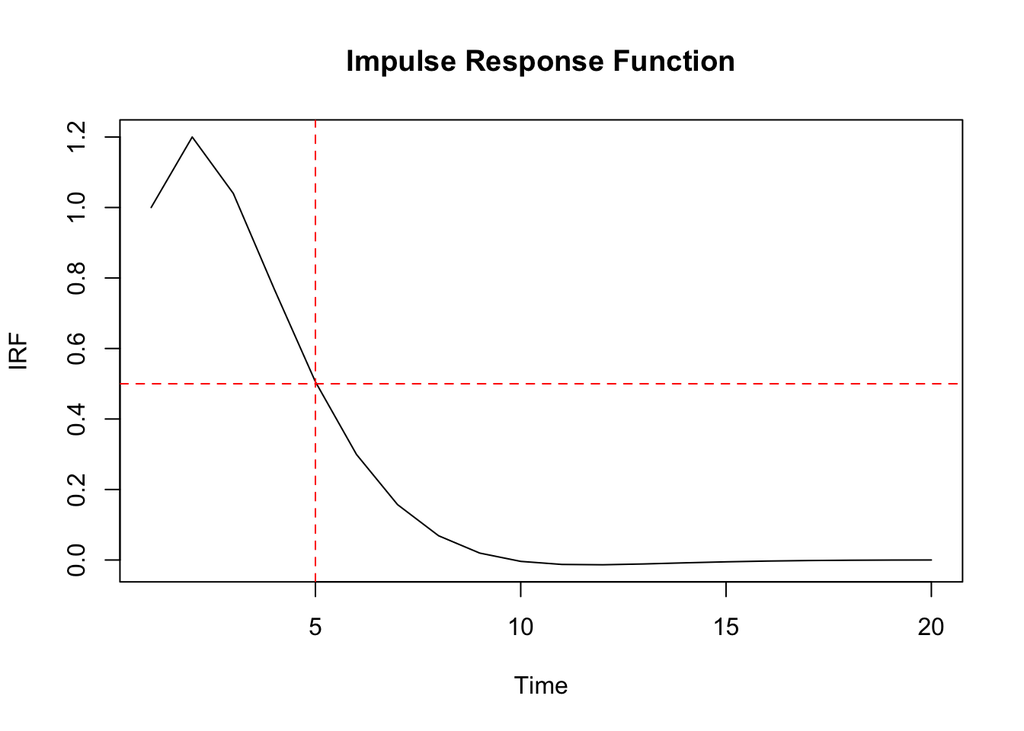

```r
set.seed(123)
e <- rnorm(n = 200, mean = 0, sd = 1)

y <- numeric(length = 200)
y.1 <- 0
y.2 <- 0
phi1 <- 1.2
phi2 <- -0.4

for (i in 1:length(y)) {
  y[i] <- phi1*y.1 + phi2*y.2 + e[i]
  y.2 <- y.1
  y.1 <- y[i]
}

# 計算IRF
irf <- numeric(length = 20)
irf[1] <- 1
for (i in 2:length(irf)) {
  if (i == 2) {
    irf[i] <- phi1
  } else {
    irf[i] <- irf[i-1]*phi1 + irf[i-2]*phi2
  }
}

# 繪製IRF
plot(irf, type = "l", main = "Impulse Response Function", xlab = "Time", ylab = "IRF")

abline(h=0.5, lty=2, col="red")
abline(v=5, lty=2, col="red")
```

```r
# 計算半衰期
distance=1
i_min <- 1
for (i in 1:length(irf)){
  if (abs(irf[i]-0.5)<distance){
    distance <- abs(irf[i]-0.5)
    i_min <- i
  }
}

i_min
```

```
## [1] 5
```

```r
irf[i_min-1]
```

```
## [1] 0.768
```

```r
irf[i_min]
```

```
## [1] 0.5056
```

```r
irf[i_min+1]
```

```
## [1] 0.29952
```

半衰期約是在t=5時。

3. $$Y_t=1.2Y_{t-1}+1.2Y_{t-2}+\epsilon_t\\
   =1.2LY_t+1.2L^2Y_t+\epsilon_t\\
   \implies (1-1.2L-1.2L^2)Y_t=\epsilon_t$$

```r
polyroot(z=c(1,-1.2,-1.2))
```

```
## [1]  0.540833-0i -1.540833+0i
```

```r
abs(polyroot(z=c(1,-1.2,-1.2)))
```

```
## [1] 0.540833 1.540833
```

其中一根的絕對值<1，因此非定態。

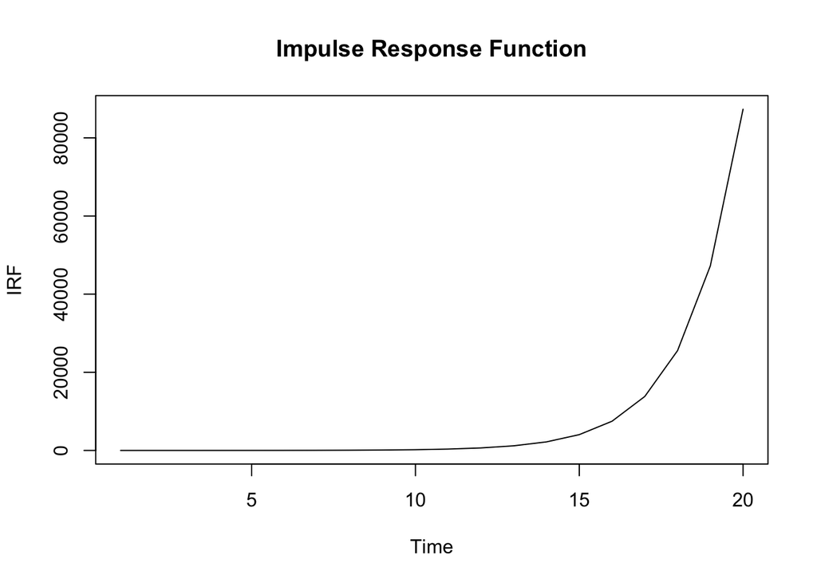

```r
set.seed(123)
e <- rnorm(n = 200, mean = 0, sd = 1)

y <- numeric(length = 200)
y.1 <- 0
y.2 <- 0
phi1 <- 1.2
phi2 <- 1.2

for (i in 1:length(y)) {
  y[i] <- phi1*y.1 + phi2*y.2 + e[i]
  y.2 <- y.1
  y.1 <- y[i]
}

# 計算IRF
irf <- numeric(length = 20)
irf[1] <- 1
for (i in 2:length(irf)) {
  if (i == 2) {
    irf[i] <- phi1
  } else {
    irf[i] <- irf[i-1]*phi1 + irf[i-2]*phi2
  }
}

# 繪製IRF
plot(irf, type = "l", main = "Impulse Response Function", xlab = "Time", ylab = "IRF")
```

4. $$Y_t=-1.2Y_{t-1}+\epsilon_t\\
   =-1.2LY_t+\epsilon_t\\
   \implies (1+1.2L)Y_t=\epsilon_t$$

```r
polyroot(z=c(1,1.2))
```

```
## [1] -0.8333333+0i
```

```r
abs(polyroot(z=c(1,1.2)))
```

```
## [1] 0.8333333
```

根的絕對值<1，因此非定態。

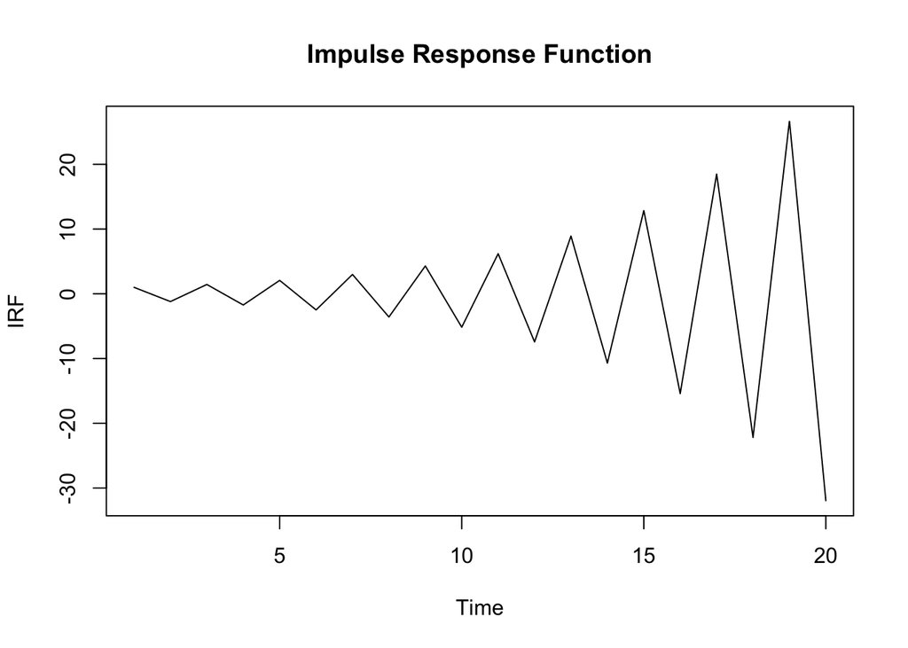

```r
set.seed(123)
e <- rnorm(n = 200, mean = 0, sd = 1)

y <- numeric(length = 200)
y.1 <- 0
phi <- -1.2

for (i in 1:length(y)) {
  y[i] <- phi*y.1 + e[i]
  y.1 <- y[i]
}

# 計算IRF
irf <- numeric(length = 20)
irf[1] <- 1
for (i in 2:length(irf)) {
  irf[i] <- irf[i-1]*phi
}

# 繪製IRF
plot(irf, type = "l", main = "Impulse Response Function", xlab = "Time", ylab = "IRF")
```

22. $$Y_t=0.7Y_{t-1}+0.25Y_{t-2}-0.175Y_{t-3}+\epsilon_t\\
    =0.7LY_t+0.25L^2Y_t-0.175L^3Y_t+\epsilon_t\\
    \implies (1-0.7L-0.25L^2+0.175L^3)Y_t=\epsilon_t$$

```r
polyroot(z=c(1,-0.7,-0.25,0.175))
```

```
## [1]  1.428571-0i -2.000000+0i  2.000000+0i
```

```r
abs(polyroot(z=c(1,-0.7,-0.25,0.175)))
```

```
## [1] 1.428571 2.000000 2.000000
```

根的絕對值>1，因此定態。

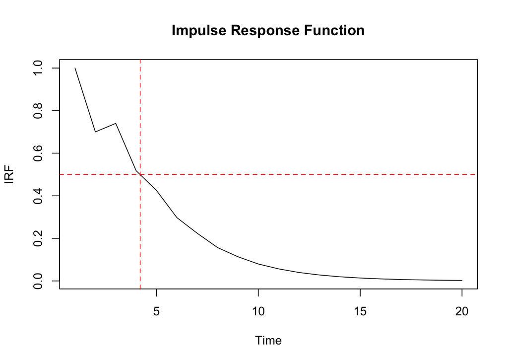

```r
set.seed(123)
e <- rnorm(n = 200, mean = 0, sd = 1)

y <- numeric(length = 200)
y.1 <- 0
y.2 <- 0
y.3 <- 0
phi1 <- 0.7
phi2 <- 0.25
phi3 <- -0.175

for (i in 1:length(y)) {
  y[i] <- phi1*y.1 + phi2*y.2+ phi3*y.3 + e[i]
  y.3 <- y.2
  y.2 <- y.1
  y.1 <- y[i]
}

# 計算IRF
irf <- numeric(length = 20)
irf[1] <- 1
irf[2] <- phi1
for (i in 3:length(irf)) {
  if(i == 3){
    irf[i] <- irf[i-1]*phi1+phi2
  } else {
    irf[i] <- irf[i-1]*phi1 + irf[i-2]*phi2+ irf[i-3]*phi3
  }
}

# 繪製IRF
plot(irf, type = "l", main = "Impulse Response Function", xlab = "Time", ylab = "IRF")
abline(h=0.5, lty=2, col="red")
abline(v=4.2, lty=2, col="red")
```

```r
# 計算半衰期
distance=1
i_min <- 1
for (i in 1:length(irf)){
  if (abs(irf[i]-0.5)<distance){
    distance <- abs(irf[i]-0.5)
    i_min <- i
  }
}
i_min
```

```
## [1] 4
```

```r
irf[i_min-1]
```

```
## [1] 0.74
```

```r
irf[i_min]
```

```
## [1] 0.518
```

```r
irf[i_min+1]
```

```
## [1] 0.4251
```

半衰期約發生在t=4時。

3.3

AR(1):
$$Y_t=\phi_0+\phi_1Y_{t-1}+\epsilon_t, \epsilon_t
\sim i.i.d.(0,\sigma^2), |\phi_1|<1, 0\le t < \infty$$

initial value: $Y_0$ be a constant

若此AR(1)模型是定態，則$E(Y_t)=\mu,\forall 0\le t < \infty$

$$E(Y_t)=E(\phi_0+\phi_1Y_{t-1}+\epsilon_t)\\
=\phi_0+\phi_1E(Y_{t-1})+E(\epsilon_t))=\\
=\phi_0+\phi_1E(Y_{t-1})\\
\implies \mu=\phi_0+\phi_1\mu\\
\implies \mu=\frac{\phi_0}{1-\phi_1}$$

In general, $E(Y_0)=Y_0 \ne \frac{\phi_0}{1-\phi_1},$

另外，$Var(Y_0)=\gamma(Y_0,Y_0)=0$,

$$Var(Y_t)=Var(\phi_0+\phi_1Y_{t-1}+\epsilon_t)\\
=\phi_1^2Var(Y_{t-1})+\sigma^2\\
\implies \sigma_Y^2=\phi_1^2\sigma_Y^2+\sigma^2\\
\implies \sigma_Y^2=\frac{\sigma^2}{1-\phi_1^2} \ne 0, \forall
t>0$$

$Cov(Y_0, Y_{0+h})=0, \forall h$

因此，若AR(1)有一固定起始值，則非定態。

3.4

若$Y_0$是隨機變數，則要滿足

- $E(Y_0)=\frac{\phi_0}{1-\phi_1}$
- $Var(Y_0)=\frac{\sigma^2}{1-\phi_1^2}$
- $\gamma(h)=Cov(Y_0, Y_{0+h}), \forall h$

才會至少是弱定態

3.19

(a). AR(1):
$$Y_t=0.5-0.95Y_{t-1}+\epsilon_t, \epsilon_t\sim
i.i.d. N(0,1)$$

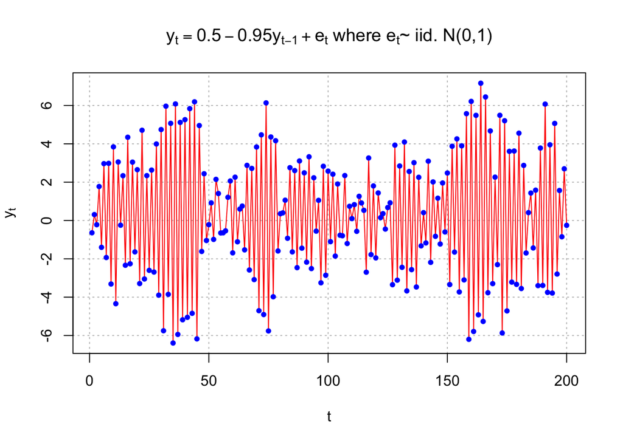

```r
set.seed(7181)
e <- rnorm(n = 200, mean = 0, sd = 1)

y <- numeric(length = 200)
y.1 <- 0
for (i in 1:length(y)) {
  y[i] <- 0.5-0.95*y.1 + e[i]
  y.1 <- y[i]
}
plot(x = y, ylab = expression(y[t]), xlab = "t", type =
  "l", col = c("red"), main =
  expression(paste(y[t] == 0.5-0.95*y[t-1] + e[t], " where ",
  e[t], "~ iid. N(0,1)" )), panel.first=grid(col =
  "gray", lty = "dotted"))
points(x = y, pch = 20, col = "blue")
```

(b). MA(1):
$$Y_t=\epsilon_t-0.95\epsilon_{t-1}, \epsilon_t\sim
i.i.d.N(0,1)$$

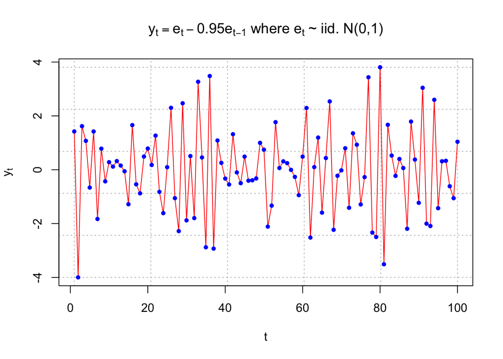

```r
set.seed(8199)
y <- arima.sim(list(ma=c(-0.95)), n=100, rand.gen=rnorm, sd=1)

plot(x = y, ylab = expression(y[t]), xlab = "t", type =
    "l", col = c("red"), main =
    expression(paste(y[t] == e[t] - 0.95*e[t-1], " where ",
    e[t], " ~ iid. N(0,1)")) , panel.first=grid(col =
    "gray", lty = "dotted"))

points(x = y, pch = 20, col = "blue")
```